# Project 2

Samuel Schmitz and David Muth

29 October, 2023

# 1 Project Scope

The scope of this analysis is to generate clean data to be used in analyzing the placement results and salary trends of FSB majors. To generate clean data ready for analysis, we will analyze each variable to assess its relevance in our model, only using/cleaning the variables we will be using. The objective of our model is to graph salary trends for FSB overall as well as different majors in FSB over the last three years. Our audience is Dr. Jones-Farmer, a shared work practitioner who will review the results of our cleaned data and provide recommendations for improving the data cleaning process.

# 2 Business Value Proposition

## 2.1 Visual

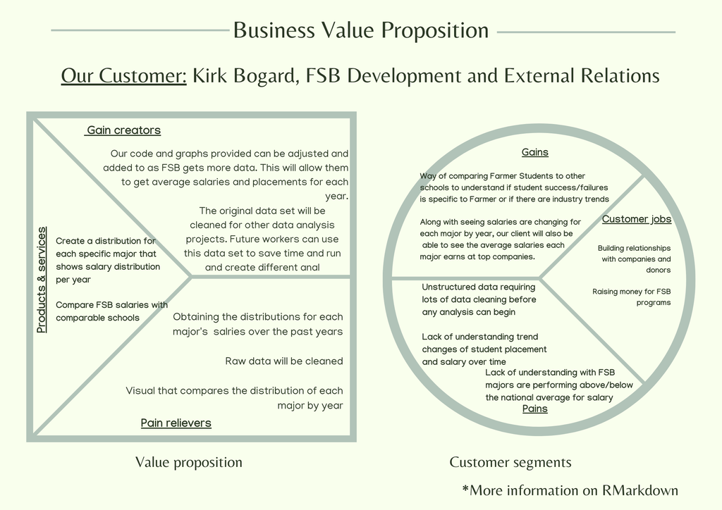

## 2.2 Written

**1. Define the client or audience for your data analysis solution.**

Our client is the Office of the Dean & External Relations. More specifically we will be working with Kirk Bogard, Associate VP for Development and External Relations in FSB.

**2. Define the client jobs. What jobs are your clients trying to get done?**

Building relationships with companies and donors

Raising money for FSB program

**3. Add pains. What are the pains before, during, and after your customer is trying to get their jobs done? Create a bullet point for every specific pain**

Unstructured data requiring lots of data cleaning before any analysis can begin

Lack of understanding trend changes of student placement and salary over time

**4. Add gains. What are the gains that your customer expects to get or will be surprised to benefit from your solution?**

Way of comparing Farmer Students to other schools to understand if student success/failures is specific to Farmer or if there are industry trends

Along with seeing salaries are changing for each major by year, our client will also be able to see the average salaries each major earns at top companies.

**5. Describe your intended solution. Give a bullet point for each major element of your product or solution.**

Create a distribution for each specific major that shows salary distribution per year

Create a bar chart that compares salaries of each major for top companies. This will allow us to see if companies alter their starting salaries for students based on major.

Compare these graphs with averages from other schools to show FSB’s success (if FSB performs better than other business schools’ average)

**6. What are the painkillers from your solution? List out those things in your solution that can kill the pain points of your client.**

Obtaining the distributions for each major’s salaries over the past years

Raw data will be cleaned

Visual that compares the distribution of each major by year

**7. What are the gain creators? List out the items that will add additional value to your customer, above and beyond addressing their current pain points.**

Our code and graphs provided can be adjusted and added to as FSB gets more data. This will allow them to get average salaries and placements for each year

The original data set will be cleaned for other data analysis projects. Future workers can use this data set to save time and run and create different analysis.

# 3 Data Introduction

## 3.1 Importing Data

```r
data = readRDS(file = "FSB_BI_Survey_2019_2021.rds")
```

## 3.2 Data Dictionary

The data set contains three years of data representing FSB graduates, including graduates in 2019, 2020, and 2021. The data set has 42 variables. The source is either derived during data cleaning/merging, from the Oracle Business Intelligence Enterprise Edition (OBIEE) maintained by Miami administration, or from the self reported senior survey. The variables and their definitions are listed below.

**nmajor**: numeric,derived, the number of majors

**major1**: text, OBIEE, first major

**major 2**: text, OBIEE, second major

**BBRJ**: binary, OBIEE, an attribute of a student, but we do not know what this stands for

**Business Direct Admit**: binary, OBIEE, a direct admit to FSB as a first year

**Combined Cacc and Masters**: binary, OBIEE, combined degree student

**Dean’s List**: binary, OBIEE, achieve dean’s list status at least once

**First Generation College Stdnt**: binary, OBIEE, first generation student status

**FSB Scholars**: binary, OBIEE, FSB scholars program

**Honors Program**: binary, OBIEE, member of University honors program

**President’s list**: binary, OBIEE, achieved president’s list at least once

**Study Abroud Courtesy Account**: binary, OBIEE, do not know meaning

**Transfer Work**: binary, OBIEE, do not know exact meaning

**Cum Laude**: binary, OBIEE, graduated Cum Laude

**Magna Cum Laude**: binary, OBIEE, graduated Magna Cum Laude

**Summa Cum Laude**: binary, OBIEE, graduated Summa Cum Laude

**University Honors**: binary, OBIEE, graduated with University Honors

**University Honors w/Distinction**: binary, OBIEE, graduated with University Honors with Distinction

**minor1**: text, OBIEE, first listed minor

**minor2**: text, OBIEE, second listed minor

**IPEDS.Race.Ethnicity**: text, OBIEE, race/ethnicity

**Gender**: text, OBIEE, sex

**GPA.Range**: text, OBIEE, GPA within a .5 range

**Term.Code**: numberic, OBIEE, First four digits are the physcal year (beginning in July, e.g. July 2020 is FY 2021). Last two digits is the term (10=fall, 15=winter, 20=spring, 30=summer)

**Year.x**: text, derived, first four digits of Term.Code stored as a character variable

**latin_honors**: text, survey, latin honors designation

**survey_city**: text, survey, student reported city in which their job is located

**survey_company**: text, survey, student reported company in which they accepted a job

**survey_deptfunc**: text, survey, student reported job function

**survey_gradprogram**: text, survey, student reported graduate program they will be attending

**survey_gradschool**: text, survey, stuent reported graduate school they will be attending

**survey_internfour**: text, survey, student reported fourth internship they held during college

**survey_internthree**: text, survey, student reported third internship they held during college

**survey_interntwo**: text, survey, student reported second internship they held during college

**survey_internone**: text, survey, student reported first internship they held during college

**Survey_internships**: text, survey, Student reported number of internships they held during college

**survey_offers**: text, survey, student reported number of offers for full time employment received

**survey_plans**: text, survey, student reported plans after graduation

**survey_pref_field**: text, survey, student reported whether working in preferred field

**survey_pref_loc**: text, survey, student reported whether working in preferred location

**survey_salary**: numeric, survey, student reported salary

**survey_state**: text, survey, student reported state in which job is located

## 3.3 Data Profile

```r
skim(data)
```

Data summary

| Name | data |
| --- | --- |
| Number of rows | 3235 |
| Number of columns | 42 |
| _______________________ |  |
| Column type frequency: |  |
| character | 20 |
| factor | 4 |
| numeric | 18 |
| ________________________ |  |
| Group variables | None |

**Variable type: character**

| skim_variable | n_missing | complete_rate | min | max | empty | n_unique | whitespace |
| --- | --- | --- | --- | --- | --- | --- | --- |
| IPEDS.Race.Ethnicity | 0 | 1.00 | 5 | 32 | 0 | 8 | 0 |
| Gender | 0 | 1.00 | 4 | 6 | 0 | 2 | 0 |
| GPA.Range | 0 | 1.00 | 11 | 11 | 0 | 5 | 0 |
| year.x | 0 | 1.00 | 4 | 4 | 0 | 3 | 0 |
| latin_honors | 0 | 1.00 | 1 | 15 | 0 | 4 | 0 |
| survey_city | 1315 | 0.59 | 2 | 22 | 0 | 299 | 0 |
| survey_company | 1238 | 0.62 | 2 | 49 | 0 | 916 | 0 |
| survey_deptfunc | 1739 | 0.46 | 3 | 161 | 0 | 257 | 0 |
| survey_gradprogram | 3047 | 0.06 | 3 | 59 | 0 | 104 | 0 |
| survey_gradschool | 3023 | 0.07 | 3 | 70 | 0 | 128 | 0 |
| survey_internfour | 3132 | 0.03 | 3 | 56 | 0 | 102 | 0 |
| survey_internone | 977 | 0.70 | 1 | 78 | 0 | 1743 | 0 |
| survey_internships | 566 | 0.83 | 1 | 3 | 0 | 8 | 0 |
| survey_internthree | 2765 | 0.15 | 1 | 60 | 0 | 382 | 0 |
| survey_interntwo | 1870 | 0.42 | 1 | 78 | 0 | 1120 | 0 |
| survey_offers | 1004 | 0.69 | 1 | 8 | 0 | 14 | 0 |
| survey_plans | 579 | 0.82 | 5 | 28 | 0 | 9 | 0 |
| survey_pref_field | 1550 | 0.52 | 2 | 3 | 0 | 2 | 0 |
| survey_pref_loc | 1631 | 0.50 | 2 | 3 | 0 | 2 | 0 |
| survey_state | 1297 | 0.60 | 2 | 28 | 0 | 126 | 0 |

**Variable type: factor**

| skim_variable | n_missing | complete_rate | ordered | n_unique | top_counts |
| --- | --- | --- | --- | --- | --- |
| major1 | 0 | 1 | FALSE | 13 | Fin: 1037, Mar: 909, Acc: 531, Sup: 244 |
| major2 | 0 | 1 | FALSE | 11 | non: 3018, Fin: 89, Mar: 48, Sup: 37 |
| minor1 | 0 | 1 | FALSE | 23 | No : 1775, Bus: 183, Hum: 180, Lan: 133 |
| minor2 | 0 | 1 | FALSE | 23 | No : 2436, Hum: 98, Lan: 96, Bus: 91 |

**Variable type: numeric**

| skim_variable | n_missing | complete_rate | mean | sd | p0 | p25 | p50 | p75 | p100 | hist |
| --- | --- | --- | --- | --- | --- | --- | --- | --- | --- | --- |
| nmajor | 0 | 1.00 | 1.07 | 0.25 | 1 | 1 | 1 | 1 | 2 | ▇▁▁▁▁ |
| BBRJ | 0 | 1.00 | 0.10 | 0.30 | 0 | 0 | 0 | 0 | 1 | ▇▁▁▁▁ |
| Business Direct Admit | 0 | 1.00 | 0.71 | 0.46 | 0 | 0 | 1 | 1 | 1 | ▃▁▁▁▇ |
| Combined Bacc and Masters | 0 | 1.00 | 0.05 | 0.21 | 0 | 0 | 0 | 0 | 1 | ▇▁▁▁▁ |
| Dean’s List | 0 | 1.00 | 0.17 | 0.38 | 0 | 0 | 0 | 0 | 1 | ▇▁▁▁▂ |
| First Generation College Stdnt | 0 | 1.00 | 0.10 | 0.30 | 0 | 0 | 0 | 0 | 1 | ▇▁▁▁▁ |
| FSB Scholars | 0 | 1.00 | 0.02 | 0.14 | 0 | 0 | 0 | 0 | 1 | ▇▁▁▁▁ |
| Honors Program | 0 | 1.00 | 0.09 | 0.29 | 0 | 0 | 0 | 0 | 1 | ▇▁▁▁▁ |
| President’s List | 0 | 1.00 | 0.04 | 0.20 | 0 | 0 | 0 | 0 | 1 | ▇▁▁▁▁ |
| Study Abroad Courtesy Account | 0 | 1.00 | 0.03 | 0.18 | 0 | 0 | 0 | 0 | 1 | ▇▁▁▁▁ |
| Transfer Work (Pre-Banner) | 0 | 1.00 | 0.10 | 0.30 | 0 | 0 | 0 | 0 | 1 | ▇▁▁▁▁ |
| Cum Laude | 0 | 1.00 | 0.23 | 0.42 | 0 | 0 | 0 | 0 | 1 | ▇▁▁▁▂ |
| Magna Cum Laude | 0 | 1.00 | 0.09 | 0.29 | 0 | 0 | 0 | 0 | 1 | ▇▁▁▁▁ |
| Summa Cum Laude | 0 | 1.00 | 0.04 | 0.19 | 0 | 0 | 0 | 0 | 1 | ▇▁▁▁▁ |
| University Honors | 0 | 1.00 | 0.07 | 0.26 | 0 | 0 | 0 | 0 | 1 | ▇▁▁▁▁ |
| UniversityHonors w/Distinction | 0 | 1.00 | 0.00 | 0.06 | 0 | 0 | 0 | 0 | 1 | ▇▁▁▁▁ |
| Term.Code | 0 | 1.00 | 202018.55 | 81.88 | 201910 | 201920 | 202020 | 202120 | 202130 | ▇▁▇▁▇ |
| survey_salary | 1503 | 0.54 | 58128.47 | 11981.13 | 10000 | 52000 | 58000 | 65000 | 175000 | ▁▇▁▁▁ |

# 4 Selection of Relevant Variables

Based on our BVP, not all variables within the data will be used. The following variables we plan on using to evaluate salary major are: **major1, survey_plans, Gender, IPEDS.Race.Ethnicity, Year.x, survey_company** and **survey_salary.**

The variables **Gender** and **IPEDS.RACE.Ethnicity** can be used for further analysis if our client is interested in comparing salries by these variables.

## 4.1 Selected Variables Levels

```r
levels(data$major1)
```

```
##  [1] "Accountancy"                    "Business Analytics"
##  [3] "Business Economics"             "Entrepreneurship"
##  [5] "Finance"                        "General Business"
##  [7] "Human Capital Mgmt& Leadership" "Information Systems"
##  [9] "Interdisciplinary Bus Managemt" "Management and Leadership"
## [11] "Management and Organizations"   "Marketing"
## [13] "Supply Chain & Operations Mgmt"
```

```r
table(data$year.x)
```

```
##
## 2019 2020 2021
## 1096 1068 1071
```

```r
table(data$survey_plans)
```

```
##
##        accepted fulltime job        accepted parttime job
##                         2007                           27
##         continuing education             military service
##                          208                           12
##       not seeking employment                        other
##                           10                           23
## seeking continuing education           seeking employment
##                           35                          333
##                self employed
##                            1
```

```r
table(data$Gender)
```

```
##
## Female   Male
##   1338   1897
```

```r
table(data$IPEDS.Race.Ethnicity)
```

```
##
## American Indian or Alaska Native                            Asian
##                                6                              101
##        Black or African American                  Hispanic/Latino
##                               43                              155
##                     Multi Racial               Non-Resident Alien
##                               85                              356
##                          Unknown                            White
##                                9                             2480
```

# 5 Date Cleaning

The variables that required cleaning were **survey_company**, **survey_plans**, and **survey_salary**.

## 5.1 survey_company

For **survey_company**, we wanted to find the companies that hire the most students from Farmer. To start, we capitalized all letters so we did not have to worry about case sensitivity while searching for frequencies. We wanted to find the companies with the highest frequencies in order to compare the salaries of each major within said companies.

```r
data$survey_company = toupper(data$survey_company)

top20companies = as.data.frame(table(data$survey_company))
top20sorted = top20companies[order(-top20companies$Freq), ]
head(top20sorted, 20)
```

|  | Var1 | Freq |
| --- | --- | --- |
| 284 | EY | 90 |
| 225 | DELOITTE | 84 |
| 655 | PWC | 40 |
| 474 | KPMG | 38 |
| 761 | TEXTRON | 34 |
| 11 | ABERCROMBIE & FITCH | 28 |
| 446 | JP MORGAN CHASE | 24 |
| 687 | RSM | 24 |
| 199 | COYOTE LOGISTICS | 22 |
| 226 | DELOITTE CONSULTING | 22 |

[output cut: 10 more lines]

We then cleaned the top companies to ensure all responses were counted for. We collapsed the levels of all companies and focused on cleaning the top 10 company names fixing spelling inconsistencies to provide a more accurate count of top companies

```r
data$survey_company = factor(data$survey_company)
```

### 5.1.1 Deloitte

```r
data$survey_company=fct_collapse(data$survey_company, "DELOITTE" = c("DELOITTE CONSULTING", "DELOITTE.", "DELOITTE, CHINA", "DELOITTE LLP", "DELOITTE TAX"))
```

### 5.1.2 DHL

```r
data$survey_company=fct_collapse(data$survey_company, "DHL" = c("DHL SUPPLY CHAIN"))
```

### 5.1.3 EY

```r
data$survey_company=fct_collapse(data$survey_company, "EY" = c("E&Y", "ERNST & YOUNG", "E AND Y", "EY (EY)", "ERNST AND YOUNG", "E & Y"))
```

### 5.1.4 KPMG

```r
data$survey_company=fct_collapse(data$survey_company, "KPMG" = c("KLYNVELD PEAT MARWICK GOERDELER"))
```

### 5.1.5 PWC

```r
data$survey_company=fct_collapse(data$survey_company, "PWC" = c("PRICEWATERHOUSECOOPERS", "PRICEWATERHOUSECOOPERS LLP", "PWC LLP"))
```

### 5.1.6 Textron

```r
data$survey_company=fct_collapse(data$survey_company, "TEXTRON" = c("TEXTRON AVIATION", "TEXTRON SPECIALIZED VEHICLES", "TEXTRON SYSTEMS", "TEXTRON SYSTEMS: LYCOMING ENGINES"))
```

### 5.1.7 Abercrombie & Fitch

```r
data$survey_company=fct_collapse(data$survey_company, "ABERCROMBIE & FITCH" = c("ABERCROMBIE"))
```

### 5.1.8 JP Morgan

```r
data$survey_company=fct_collapse(data$survey_company, "JP MOGAN CHASE" = c("JP MORGAN", "JPMORGAN", "JPMORGAN CHASE", "J.P. MORGAN", "J.P MORGAN", "JPMORGAN CHASE & CO.", "JP MORGAN AND CHASE", ""))
```

### 5.1.9 RSM

There were no misspellings or inconsistencies for RSM.

### 5.1.10 Coyote Logistics

```r
data$survey_company=fct_collapse(data$survey_company, "COYOTE LOGISTICS" = c("COYOTELOGISTICS", "COYOTE"))
```

### 5.1.11 Finalized Company Count

```r
top20companies = as.data.frame(table(data$survey_company))
top20sorted = top20companies[order(-top20companies$Freq), ]
head(top20sorted, 10)
```

|  | Var1 | Freq |
| --- | --- | --- |
| 223 | DELOITTE | 109 |
| 267 | EY | 106 |
| 746 | TEXTRON | 51 |
| 629 | PWC | 43 |
| 460 | KPMG | 38 |
| 10 | ABERCROMBIE & FITCH | 29 |
| 229 | DHL | 25 |
| 434 | JP MORGAN CHASE | 24 |
| 672 | RSM | 24 |
| 197 | COYOTE LOGISTICS | 23 |

## 5.2 survey_salary

We imputed the average salary for each major per year for all responses with a missing salary response.

```r
imputed_data = data %>%
  group_by(major1, year.x) %>%
  dplyr::mutate(survey_salary=ifelse(is.na(survey_salary), mean(survey_salary, na.rm = TRUE), survey_salary)) %>%
  ungroup()
```

## 5.3 survey_plans

We created a new data set from the original only keeping observations for students who said they have accepted a full-time or part-time job. We ignored observations for students continuing education, joining the military, etc..

```r
filtered_data <- imputed_data %>%
  filter(survey_plans %in% c("accepted fulltime job", "accepted parttime job"))
head(filtered_data)
```

| nmajor | major1 | major2 | BBRJ | Business Direct Admit | Combined Bacc and Masters | Dean's List | First Generation College Stdnt | FSB Scholars | Honors Program | President's List | Study Abroad Courtesy Account | Transfer Work (Pre-Banner) | Cum Laude | Magna Cum Laude | Summa Cum Laude | University Honors | UniversityHonors w/Distinction | minor1 | minor2 | IPEDS.Race.Ethnicity | Gender | GPA.Range | Term.Code | year.x | latin_honors | survey_city | survey_company | survey_deptfunc | survey_gradprogram | … |
| --- | --- | --- | --- | --- | --- | --- | --- | --- | --- | --- | --- | --- | --- | --- | --- | --- | --- | --- | --- | --- | --- | --- | --- | --- | --- | --- | --- | --- | --- | --- |
| 1 | Finance | none | 0 | 1 | 0 | 0 | 0 | 0 | 0 | 0 | 0 | 0 | 0 | 0 | 0 | 0 | 0 | Business Legal Studies | No Minor | White | Male | 3.00 - 3.49 | 201920 | 2019 | 0 | Toledo | BAM NUTUAL | Finance | NA | … |
| 1 | Marketing | none | 0 | 1 | 0 | 1 | 0 | 0 | 0 | 0 | 0 | 0 | 1 | 0 | 0 | 0 | 0 | Humanities | Humanities | Asian | Female | 3.50 - 4.00 | 202120 | 2021 | 0 | Columbus | COHATCH | General Management | NA | … |
| 1 | Finance | none | 0 | 1 | 0 | 0 | 1 | 0 | 0 | 0 | 0 | 0 | 0 | 0 | 0 | 0 | 0 | Accountancy | Accountancy | White | Male | 3.00 - 3.49 | 202020 | 2020 | 0 | NA | PWC | NA | NA | … |
| 1 | Marketing | none | 0 | 1 | 0 | 1 | 0 | 0 | 0 | 0 | 0 | 0 | 0 | 0 | 0 | 0 | 0 | Supply Chain Management | Supply Chain Management | White | Male | 3.00 - 3.49 | 201920 | 2019 | 0 | Columbus | ABERCROMBIE & FITCH | General Management | NA | … |
| 1 | Marketing | none | 0 | 1 | 0 | 0 | 0 | 0 | 0 | 0 | 0 | 1 | 0 | 0 | 0 | 0 | 0 | Humanities | Humanities | White | Female | 3.00 - 3.49 | 202020 | 2020 | 0 | Cleveland | MCDONALD'S | Consulting Marketing / Sales Operations / Procurement | NA | … |
| 1 | Finance | none | 0 | 1 | 0 | 0 | 0 | 0 | 0 | 0 | 0 | 0 | 1 | 0 | 0 | 0 | 0 | Economics | No Minor | White | Female | 3.50 - 4.00 | 201920 | 2019 | Cum Laude | Chicago | EY | Analytics\r\n Consulting | NA | … |

# 6 Top Companies Data Frame

This data includes only observations for students that landed a job at one of the top 10 companies (based on total hires).

```r
top_companies_data = filtered_data %>%
filter(survey_company %in% c("DELOITTE", "PWC", "EY", "KPMG", "TEXTRON", "ABERCROMBIE & FITCH", "DHL", "JP MORGAN CHASE", "RSM", "COYOTE LOGISTICS"))
```

# 7 Saving Data

```r
write.csv(filtered_data, "clean_data.csv", row.names = FALSE)


write.csv(top_companies_data, "top_companies.csv", row.names = FALSE)
```